# Simulating different split proportions for discovery and replication

Gibran Hemani

2021-03-29

```r
suppressPackageStartupMessages(suppressWarnings({
    library(dplyr)
    library(ggplot2)
    library(simulateGP)
    library(knitr)
    library(gridExtra)
}))
opts_chunk$set(cache=TRUE, echo=TRUE, message=FALSE, warning=FALSE)
```

We can split the UKBB data to obtain discovery and replication effect estimates for a GWAS. We can use the replication sample as the outcome sample in an MR analysis. If sample A is used for discovery of exposure instruments, and sample B is used for replicating the exposure instruments and estimating the outcome effects, what proportion of samples should be in A or B?

Expect that larger sample size for discovery will lead to more instruments and therefore greater power. However, larger sample in B will lead to more precision of SNP-outcome estimate therefore more power. On balance, an even split likely to be overall most powerful.

Does this change for different genetic architectures?

Simple simulations to look at this - vary proportion of samples in A (remainder are in B), and vary genetic architectures.

Note: These simulations operate by generating GWAS summary data directly, not by generating individuals with true sample overlap. Previous simulations suggested that having sample overlap between exposure replication estimates and SNP-outcome estimates was not a big problem, and similar to the scenario where SNP-outcome estimates were from an entirely independent sample. These simulations mimic the latter, where the SNP-outcome estimate is from an entirely independent sample.

Parameters:

```r
param <- expand.grid(
    nid = 450000,
    propA = seq(0.1, 0.9, by=0.1),
    h2 = seq(0.1, 0.9, by=0.2),
    nsnp = c(5000, 10000),
    bxy = 0.2,
    minmaf = 0.1,
    maxmaf = 0.5,
    S = 0,
    threshold = 5e-8,
    sim = 1:100
)
dim(param)
```

```
## [1] 9000   10
```

Simulations:

```r
runsim <- function(p)
{
    map <- tibble(snp=1:p$nsnp, af=runif(p$nsnp, p$minmaf, p$maxmaf))
    paramx <- simulateGP::generate_gwas_params(map, p$h2, p$S)
    paramy <- paramx
    paramy$beta <- paramy$beta * p$bxy
    ndisc <- round(p$nid * p$propA)
    nrepl <- p$nid - ndisc
    discx <- simulateGP::generate_gwas_ss(paramx, ndisc)
    replx <- simulateGP::generate_gwas_ss(paramx, nrepl)
    reply <- simulateGP::generate_gwas_ss(paramy, nrepl)
    sigsnp <- discx$snp[discx$pval < p$threshold]

    if(length(sigsnp) > 1 | length(sigsnp) == 0)
    {
        res <- TwoSampleMR::mr_ivw(replx$bhat[sigsnp], reply$bhat[sigsnp], replx$se[sigsnp], reply$se[sigsnp])
    } else {
        res <- TwoSampleMR::mr_wald_ratio(replx$bhat[sigsnp], reply$bhat[sigsnp], replx$se[sigsnp], reply$se[sigsnp])
    }
    p$nsig <- length(sigsnp)
    p$ivw_b <- res$b
    p$ivw_se <- res$se
    p$ivw_pval <- res$pval
    return(p)
}
```

Run:

```r
l <- list()
for(i in 1:nrow(param))
{
    l[[i]] <- runsim(param[i,])
}
l <- bind_rows(l)
```

Summarise:

```r
lsum <- l %>%
    filter(!is.na(ivw_b)) %>%
    group_by(nid, h2, nsnp, bxy, minmaf, maxmaf, S, threshold, propA) %>%
    summarise(n=n(), nsig=mean(nsig, na.rm=T), pow=sum(ivw_pval < 0.05, na.rm=T)/n(), b=mean(ivw_b, na.rm=T), z = mean(ivw_b/ivw_se, na.rm=T))
save(l, lsum, file="summary_sims.rdata")
```

Plot the test statistic for the MR result - higher Z value means higher power - against the proportion of samples in A:

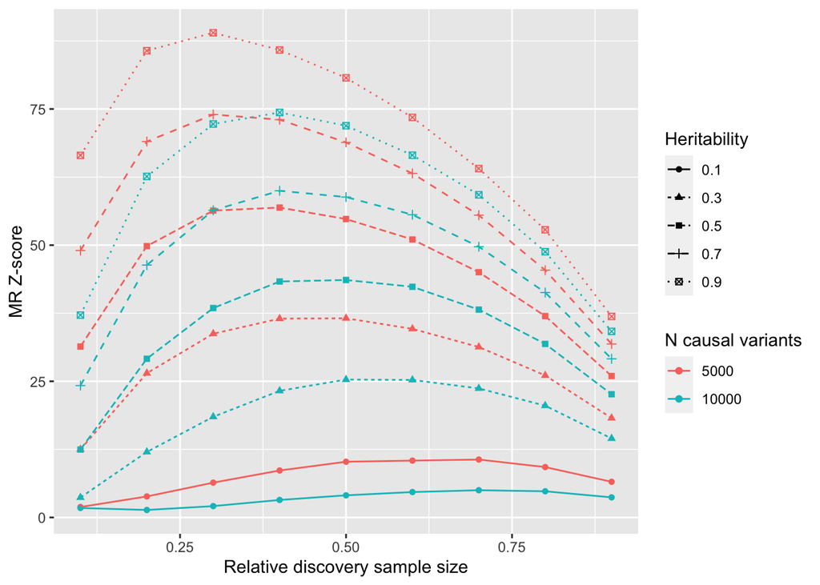

```r
p1 <- ggplot(lsum, aes(y=z, x=propA, group=as.factor(nsnp * h2))) +
geom_point(aes(colour=as.factor(nsnp), shape=as.factor(h2))) +
geom_line(aes(colour=as.factor(nsnp), linetype=as.factor(h2))) +
labs(shape="Heritability", linetype="Heritability", colour="N causal variants", y="MR Z-score", x="Relative discovery sample size")
p1
```

Generally the power is maximised somewhere in the middle, but the point of maximisation does change with different architectures. In general, a 50/50 split seems fine.

Is bias changing with different values of propA?

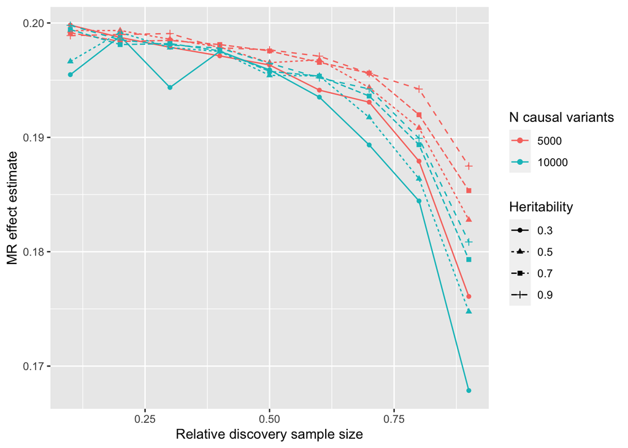

```r
p2 <- ggplot(lsum %>% filter(h2 != 0.1), aes(y=b, x=propA, group=as.factor(nsnp * h2))) +
geom_point(aes(colour=as.factor(nsnp), shape=as.factor(h2))) +
geom_line(aes(colour=as.factor(nsnp), linetype=as.factor(h2))) +
labs(shape="Heritability", linetype="Heritability", colour="N causal variants", y="MR effect estimate", x="Relative discovery sample size")
p2
```

Looks like weak instrument bias increases when the replication sample is smaller.

How many instruments are being discovered?

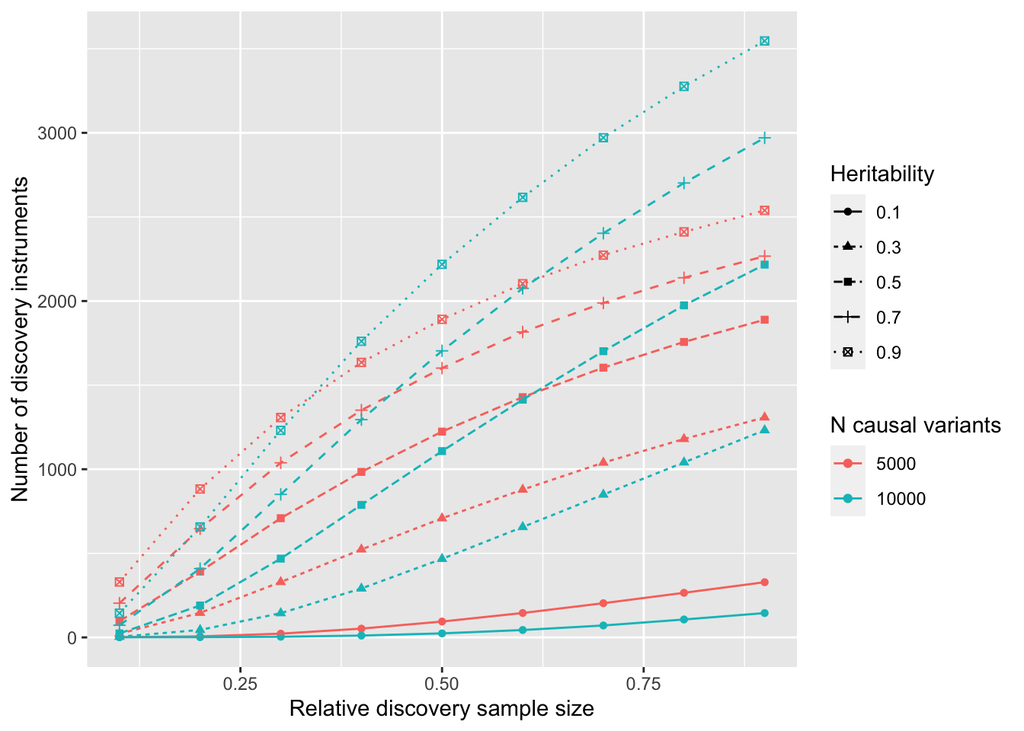

```r
p3 <- ggplot(lsum, aes(y=nsig, x=propA, group=as.factor(nsnp * h2))) +
geom_point(aes(colour=as.factor(nsnp), shape=as.factor(h2))) +
geom_line(aes(colour=as.factor(nsnp), linetype=as.factor(h2))) +
labs(shape="Heritability", linetype="Heritability", colour="N causal variants", y="Number of discovery instruments", x="Relative discovery sample size")
p3
```

```r
g_legend<-function(a.gplot)
{
    tmp <- ggplot_gtable(ggplot_build(a.gplot))
    leg <- which(sapply(tmp$grobs, function(x) x$name) == "guide-box")
    legend <- tmp$grobs[[leg]]
    return(legend)
}
mylegend <- g_legend(p1 + theme(legend.position="bottom"))
p4 <- grid.arrange(
    mylegend, arrangeGrob(p1 + theme(legend.position="none") + labs(x="", title="A"),
                p2 + theme(legend.position="none") + labs(x="", title="B"),
                p3 + theme(legend.position="none") + labs(x="Relative discovery sample size", title="C"),
                nrow=3),
    nrow=2, heights=c(1, 10)
)
```

[figure not shown]